# Assignment 4

Yvonne Dinh

11/18/2020

### Introduction

This assignment explores data on the juvenile snowshoe hares recorded at Bonanza Creek LTER from 1999 - 2012. Using statistical methods, hare trapping counts, hare weights, and hare hind foot length are explored and visualized.

### Exploratory findings

#### A. Annual juvenile hare trap counts

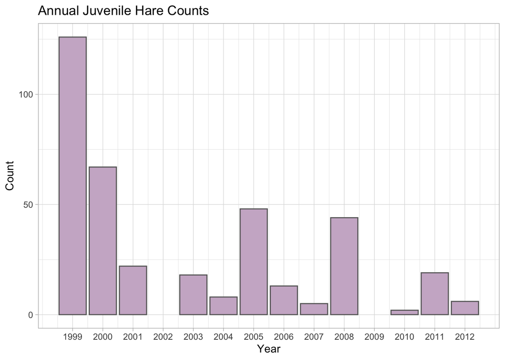

Fig 1. Counts of juvenile hare trappings from 1999 - 2012. Data: Kielland et al. (2017).

The minimum and maximum annual trap counts are 2 and 126, respectively, the mean is 31.5, and the median is 18.5. Looking at the figure, there seems to be a general trend that there were more hare trappings in the earlier years than in the more recent years. This might be due to differences in other variables that may influence trap count, such as the amount of traps that were set up and how often the traps were set up. To account for these differences, the study could be more standardized by setting up a set amount of traps at certain times of the day for a set time period.

#### B. Juvenile hare weights

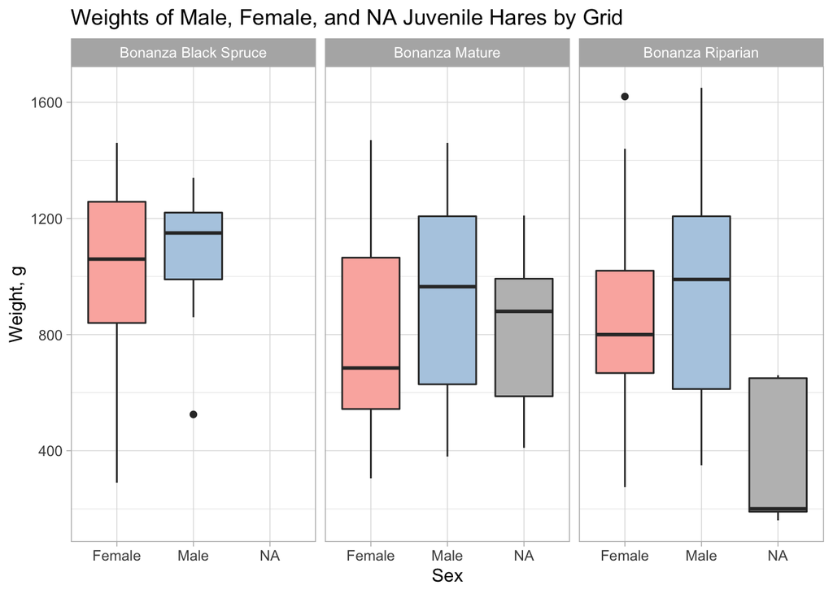

Fig 2. Box plot of weights for female, male, and NA juvenile hares at each of the three trapping grids. Data: Kielland et al. (2017).

Across all trapping grids, the median juvenile female hare weights are lower than the male median hare weights. There were outlier weights in the male hares in the Bonanza Black Spruce grid and female hares in the Bonanza Riparian grid. For the most part, whisker lengths were larger in the female hares than in the male hares, indicating a larger range in weights in females than in males.

#### C. Juvenile weight comparison between sexes

Table 1. Descriptive statistics (mean, standard deviation, and sample size) for female and male juvenile hares. Data: Kielland et al. (2017).

| Sex | Mean (g) | Standard Deviation (g) | Sample Size |
| --- | --- | --- | --- |
| Female | 855.3909 | 292.2526 | 200 |
| Male | 945.8589 | 333.2151 | 163 |

The actual difference in means between the weights of female and male juvenile hares is 90.4680328 g. After running a two-sample t-test, the p-value is *p* = 0.0071, meaning that there is a 0.0071 probability of getting two sample means with the same mean difference we observed. Since the p-value is really small, it is very unlikely that these samples were drawn from populations with the same mean. However, after running a Cohen’s test to determine the effect size of the data, we find a small effect size (-0.29), indicating that the magnitude of the difference between the male and female weights is not that large. This can be explained by the large variability in weights, especially in the juvenile male hares.

#### D. Relationship between juvenile weight and hind foot length

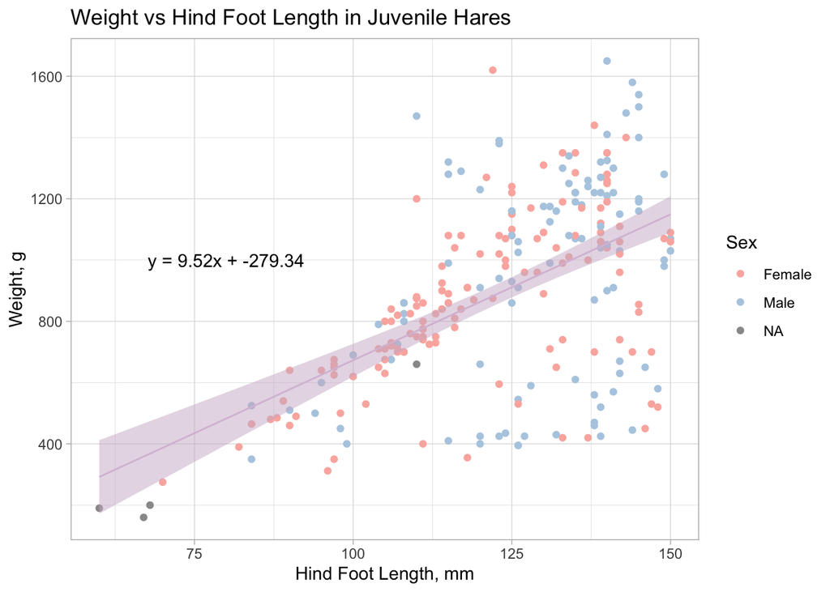

Fig 3. Relationship between weight (g) and hind foot length (mm) in juvenile hares. Each point indicates an individual hare measurement, with pink points as female hares, blue points as male hares, and gray points as hares who were not sexed. A linear model was fit to the data, with the equation y = 9.52x + -279.34. Data: Kielland et al. (2017).

The linear regression model suggests that the equation of the line is y = 9.52x + -279.34, the R<sup>2</sup> value is 0.2987695, the p-value is 0, and the Pearson’s r is 0.5466. This linear regression model assumes that the data is homoscedastic, however, there is a lot of variability in hare weight as hind foot length increases. This is indicated by the low R-squared value, which tells us that 29.9% of variance in weight is predictable from hind foot length. Further, if we only looked at juvenile hare data for hares that had a hind foot length of greater than 125, the linear regression model would look very different.

### Citations

Kielland, K., F.S. Chapin, R.W. Ruess, and Bonanza Creek LTER. 2017. Snowshoe hare physical data in Bonanza Creek Experimental Forest: 1999-Present ver 22. Environmental Data Initiative. (https://doi.org/10.6073/pasta/03dce4856d79b91557d8e6ce2cbcdc14)